# DEMONSTRATIVE SIMULATION OF THE CENTRAL LIMIT THEOREM

Oluwadare, Margaret

8/27/2020

## SYNOPSIS

This project is to investigate the exponential distribution and compare it to the Central Limit Theorem. For this particular case the distribution parameter lambda will be set to 0.2 for all of the simulations. We will be comparing the distribution of 40 averages of exponentials distribution over 1000 simulations.

## SIMULATIONS:

The exponential distribution can be simulated in R with `rexp(n, lambda)`, where `lambda` is the rate parameter and `n` is the number of observations. For the purpose of this project value of `lambda` is set to `0.2`. First we load the `ggplot2` plotting library.

```r
library(ggplot2)
```

```r
numcases <- 1000              #how many samples to take?
lambda <- 0.2
ntimes <- 40
```

Set the seed of the random number generator for reproducibility.

```r
set.seed(1234)
```

Perform simulations

```r
i2 <- 1                     #initialize counters

for (i in 1:ntimes)               #repeat n times
{  sample <- 0 ;
  k <- 0                #start off with an empty set of counters
for (j in 1:i2)          #  inner loop
{
  sample <- sample +matrix(rexp(ntimes * numcases, rate = lambda), numcases)
  k <- k+1  }
x <- sample/k
out <- c(k,mean(x),sd(x))
}
```

compute the mean for each of the 1000 simulations(rows)

```r
simulationMean <- rowMeans(x)
```

We plot the simulation data to visualize it

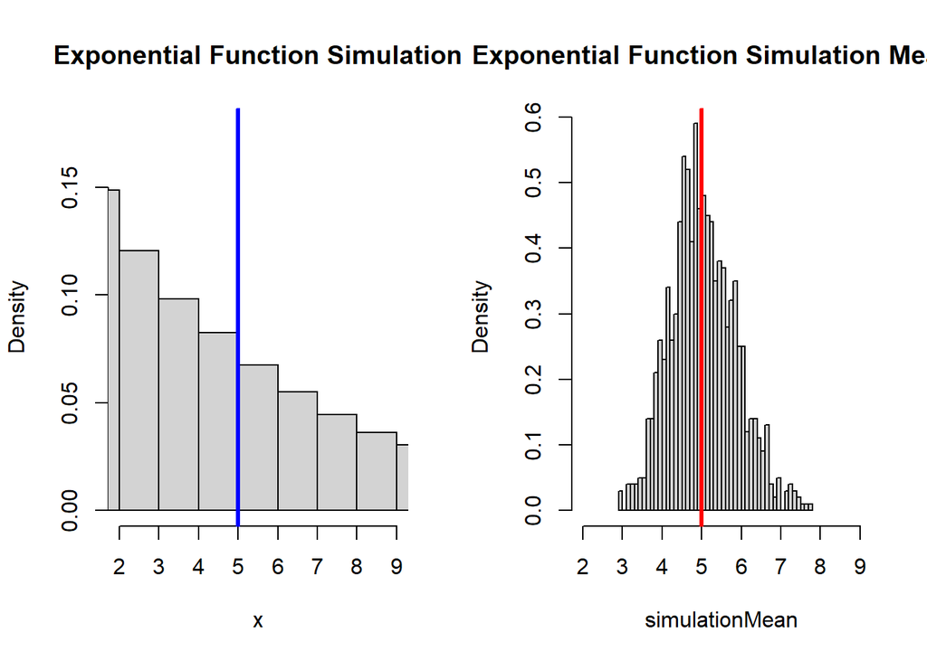

```r
par(mfrow = c(1,2))
hist(x, prob = T, breaks = 40, xlim = c(2,9), main = paste( "Exponential Function Simulation" ))
abline(v = lambda^-1, col = "blue", lwd = 3)

hist(simulationMean, prob = T,  breaks = 40, xlim = c(2,9), main = paste( "Exponential Function Simulation Means" ))
abline(v = lambda^-1, col = "red", lwd = 3)
```

## SAMPLE MEAN VS THEORETICAL MEAN

Sample mean is simply the mean of the simulated average values of the exponentials. Theoretical mean of the average values of exponentials is 1/lambda. We will plot the distribution of the average exponentials using histogram.

```r
sample_mean <- mean(simulationMean)
sample_mean
```

```
## [1] 5.042438
```

```r
theo_mean <- 1/lambda
theo_mean
```

```
## [1] 5
```

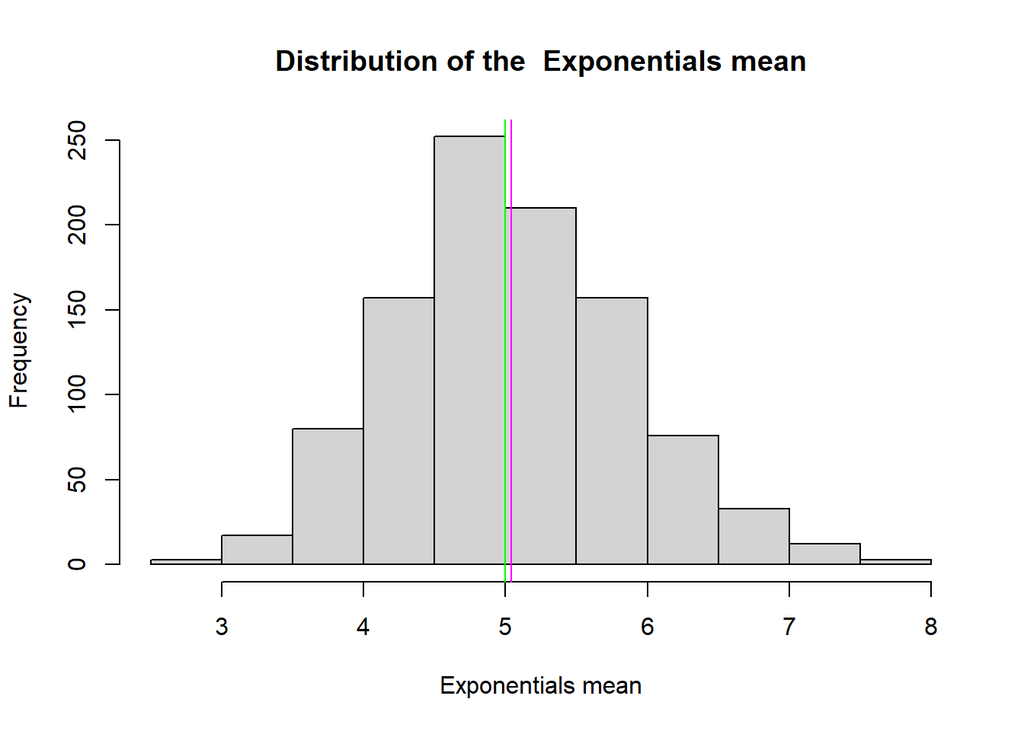

```r
hist(simulationMean, xlab = "Exponentials mean", main = "Distribution of the  Exponentials mean")
abline(v = sample_mean, col = "magenta")
abline(v = theo_mean, col = "green")
```

The sample mean is 5.042438 while the theoretical mean is 5. As seen in the histogram, the sample mean of the average exponentials (magenta vertical line) is close to the theoretical mean of an exponential distribution (green vertical line).

## VARIANCE COMPARISON

The following code will compute the actual varaince of the simualted mean

```r
sample_var <- var(simulationMean)
sample_sd <- sd(simulationMean)
theo_var  <- (1 / lambda)^2 / (ntimes)
theo_sd  <- 1/(lambda * sqrt(ntimes))

sample_var
```

```
## [1] 0.6788525
```

```r
sample_sd
```

```
## [1] 0.8239251
```

```r
theo_var
```

```
## [1] 0.625
```

```r
theo_sd
```

```
## [1] 0.7905694
```

From our result, we can see that the actual variance (0.6789) of the simulated mean sample data is very close to the theoretical variance (0.625) of original data distribution.

## EXAMINE THE NORMALITY OF THE EXPONENTIALS AVERAGES DISTRIBUTION

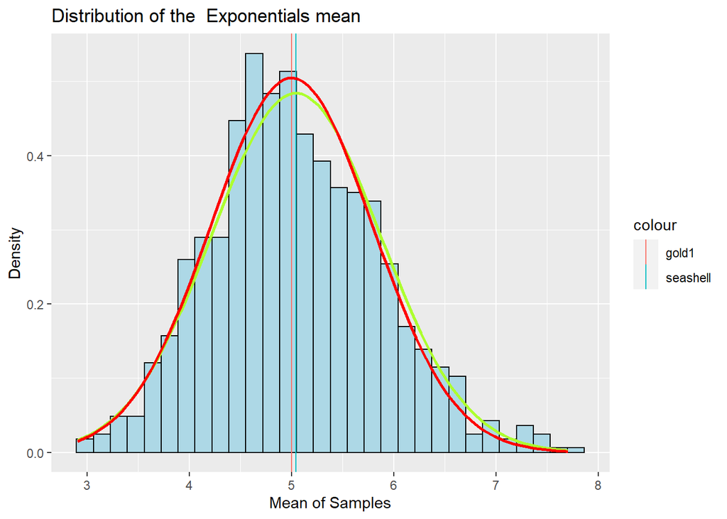

```r
par(mfrow = c(1,2))
plotdata <- data.frame(simulationMean)
distplot <- ggplot(plotdata, aes(x = simulationMean))
distplot <- distplot + geom_histogram(aes(y = ..density..), colour = "black",
                        fill = "lightblue")
distplot <- distplot + labs(title = "Distribution of the  Exponentials mean", x = "Mean of Samples", y = "Density")
distplot <- distplot + geom_vline(aes(xintercept = sample_mean, colour = "seashell"))
distplot <- distplot + geom_vline(aes(xintercept = theo_mean, colour = "gold1" ))
distplot <- distplot + stat_function(fun = dnorm, args = list(mean = sample_mean, sd = sample_sd), color = "greenyellow", size = 1.0)
distplot <- distplot + stat_function(fun = dnorm, args = list(mean = theo_mean, sd = theo_sd), colour = "red", size = 1.0)
distplot
```

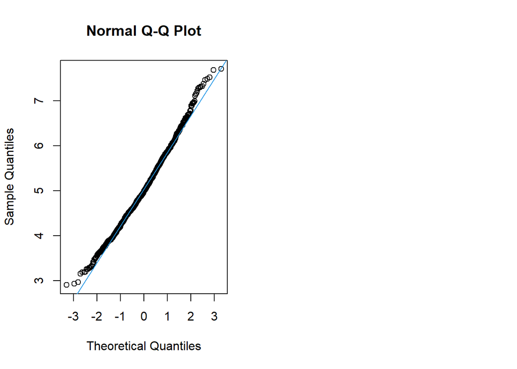

```r
qqnorm(simulationMean)
qqline(simulationMean, col = 4)
```

## CONFIDENCE INTERVAL COMPARISON

Next we check the confidence interval levels to see how they compare.

## Sample CI

To Calculate the sample confidence interval using sampleCI = mean of x plus or minus the 97.5th normal quantile times the standard error of the mean standard deviation of x divided by the square root of n (the length of the vector x).

```r
sampleCI <- round(mean(simulationMean) + c(-1,1)*1.96*sample_sd/sqrt(ntimes),3)
sampleCI
```

```
## [1] 4.787 5.298
```

## Theoretical CI

To Calculate the theoretical confidence interval we use theoCI = theoMean of x plus or minus the 97.5th normal quantile times the standard error of the mean standard deviation of x divided by the square root of n (the length of the vector x).

```r
theoCI <- theo_mean+ c(-1,1) * 1.96 * sqrt(theo_var)/sqrt(ntimes)
theoCI
```

```
## [1] 4.755 5.245
```